# R Notebook

```r
library(tidyverse)
library(janitor)
```

# Q1

Load and explore the data held in heart.csv. A data dictionary is also available.

```r
heart <- read_csv("data/heart.csv")
```

# Q2

Plot a histogram and/or boxplot for thalach (maximum heart rate achieved in stress testing). How normal is the distribution?

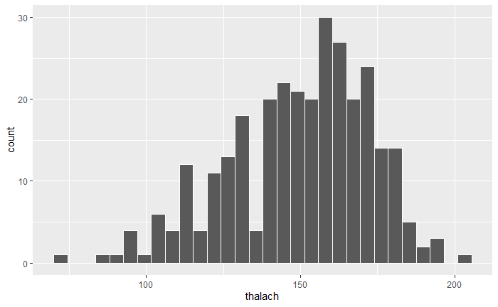

```r
heart %>%
  ggplot(aes(thalach)) +
  geom_histogram(col = "white")
```

Data is somewhat normal although it is skewed to the left.

# Q3

Also plot a barplot of exang (whether the patient displayed exercise induced angina)

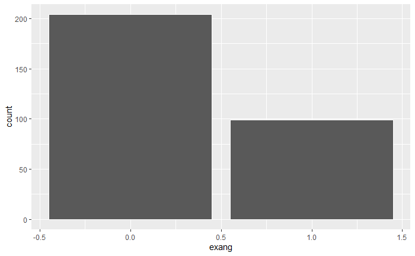

```r
heart %>%
  ggplot(aes(exang)) +
  geom_bar(col = "white")
```

# Q4

Now calculate population parameters: what is the mean thalach in the population. What proportion of patients have exercise induced angina (exang)?

```r
heart_pop <- heart %>%
  summarise(mean_thalach = mean(thalach),
  prop_exang = mean(exang))

heart_pop
```

| mean_thalach | prop_exang |
| --- | --- |
| 149.6469 | 0.3267327 |

```r
NA
```

# Q5

Now take a single sample of 50-patients from the population and calculate point estimates for mean thalach and proportion of exang from this sample (let’s call these mean_thalach and prop_exang going forward).

```r
library(infer)

heart_s50 <- heart %>%
  rep_sample_n(50) %>%
  ungroup()

heart_s50_stat <- heart_s50 %>%
  summarise(mean_thalach = mean(thalach),
            prop_exang = mean(exang))
```

# Q6

What are the sampling errors of these point estimates?

```r
se_heart_s50 <- heart_s50_stat - heart_pop

se_heart_s50
```

| mean_thalach | prop_exang |
| --- | --- |
| -0.3868647 | -0.02673267 |

```r
NA
```

# Q7

Now we’re going to repeatedly sample 50-patients from the population and build up sampling distributions for the mean_thalach and prop_exang point estimates. Take 5000 samples and store the sampling distributions in a variable rep_sample_50.

```r
rep_sample_50 <- heart %>%
  rep_sample_n(50, reps = 5000) %>%
  summarise(mean_thalach = mean(thalach),
            prop_exang = mean(exang))

rep_sample_50
```

| replicate | mean_thalach | prop_exang |
| --- | --- | --- |
| 1 | 152.56 | 0.34 |
| 2 | 149.20 | 0.32 |
| 3 | 146.80 | 0.34 |
| 4 | 149.58 | 0.30 |
| 5 | 146.70 | 0.40 |
| 6 | 152.16 | 0.32 |
| 7 | 149.04 | 0.30 |
| 8 | 145.08 | 0.32 |
| 9 | 155.36 | 0.30 |
| 10 | 151.98 | 0.30 |

[output cut: 990 more lines]

```r
NA
```

# Q8

Visualise the sampling distributions of mean_thalach and prop_exang as histograms. How normal do the sampling distributions look?

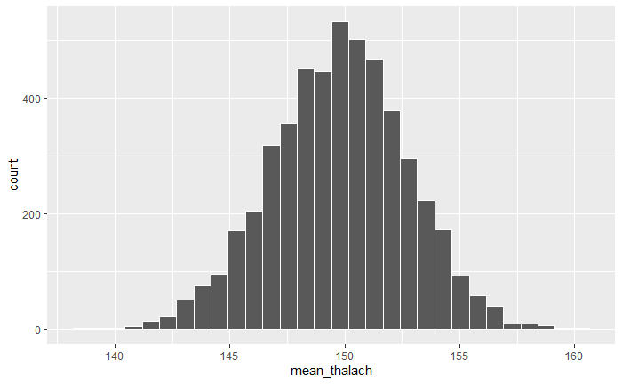

```r
thalach_s50 <- rep_sample_50 %>%
  ggplot(aes(mean_thalach)) +
  geom_histogram(col = "white")

thalach_s50
```

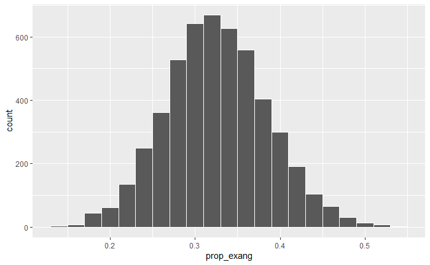

```r
exang_s50 <- rep_sample_50 %>%
  ggplot(aes(prop_exang)) +
  geom_histogram(binwidth = 0.02, col = "white")

exang_s50
```

Both distributions follow the shape of a normal distribution.

# Q9

Obtain standard errors of the sampling distribution of mean_thalach and prop_exang directly as the standard deviations of the sampling distributions held in rep_sample_50.

```r
rep_sample_50_stats <- rep_sample_50 %>%
  summarise(mean_thalach = mean(mean_thalach),
            prop_exang = mean(prop_exang))

se_rep_sample_50 <- rep_sample_50_stats - heart_pop

se_rep_sample_50
```

| mean_thalach | prop_exang |
| --- | --- |
| 0.1078753 | -0.001060673 |

```r
NA
```

# Q10

Repeat steps 7. and 9. (omitting step 8.) once more with samples of size 100-patients, and again with samples of size 200-patients. How do the standard errors of mean_thalach and prop_exang change as sample size increases? Does the uncertainty in the calculated statistics increase or decrease as sample size increases?

## 50 samples

```r
rep_sample_50 <- heart %>%
  rep_sample_n(50, reps = 5000) %>%
  summarise(mean_thalach = mean(thalach),
            prop_exang = mean(exang))


rep_sample_50_stats <- rep_sample_50 %>%
  summarise(mean_thalach = mean(mean_thalach),
            prop_exang = mean(prop_exang))

se_rep_sample_50 <- rep_sample_50_stats - heart_pop

se_rep_sample_50
```

| mean_thalach | prop_exang |
| --- | --- |
| 0.08654331 | -0.001036673 |

```r
NA
```

## 100 samples

```r
rep_sample_100 <- heart %>%
  rep_sample_n(100, reps = 5000) %>%
  summarise(mean_thalach = mean(thalach),
            prop_exang = mean(exang))


rep_sample_100_stats <- rep_sample_100 %>%
  summarise(mean_thalach = mean(mean_thalach),
            prop_exang = mean(prop_exang))

se_rep_sample_100 <- rep_sample_100_stats - heart_pop

se_rep_sample_100
```

| mean_thalach | prop_exang |
| --- | --- |
| -0.002360686 | 0.0008533267 |

```r
NA
```

## 200 samples

```r
rep_sample_200 <- heart %>%
  rep_sample_n(200, reps = 5000) %>%
  summarise(mean_thalach = mean(thalach),
            prop_exang = mean(exang))


rep_sample_200_stats <- rep_sample_200 %>%
  summarise(mean_thalach = mean(mean_thalach),
            prop_exang = mean(prop_exang))

se_rep_sample_200 <- rep_sample_200_stats - heart_pop

se_rep_sample_200
```

| mean_thalach | prop_exang |
| --- | --- |
| -0.0001736865 | 0.0002543267 |

```r
NA
```

```r
# create summary table
se_rep_sample_50 %>%
  bind_rows(se_rep_sample_100,
         se_rep_sample_200) %>%
  mutate(samples = c(50, 100, 200), .before = mean_thalach)
```

| samples | mean_thalach | prop_exang |
| --- | --- | --- |
| 50 | 0.0865433135 | -0.0010366733 |
| 100 | -0.0023606865 | 0.0008533267 |
| 200 | -0.0001736865 | 0.0002543267 |

```r
NA
```

The standard error decreases as the number of samples increases indicating that a higher number of samples give greater confidence that the mean values are converging to the true population mean.